# Assignment 13: Text Mining

1. Use the description to predict if a movie/TV show is in 20th or 21st century. Give the accuracy and plot the confusion matrix table.

```r
## Unable to run this cell because I can not install the textrecipes package (removed from CRAN repository as of 11/13/23). Also had to comment out so I could knit and submit this assignment.

####################################### Giving Accuracy ##################################
# library(caret)
# library(themis)
# library(textrecipes)
#
# # Select data and set target
# model_df <- df %>%
#   mutate(target = century) %>%
#   select(target, description)
#
# # Convert text data to numeric variables
# a <- recipe(target~description,
#        data = df) %>%
#   step_tokenize(description) %>%
#   step_tokenfilter(description, max_tokens = 50) %>%
#   step_tfidf(description) %>%
#   step_normalize(all_numeric_predictors()) %>%
#   step_smote(target) %>%
#   prep()
# model_df <- juice(a)
#
# # Using Caret for modeling
# set.seed(2021)
# splitIndex <- createDataPartition(model_df$target, p = .7,
#                                   list = FALSE)
# df_train <- model_df[ splitIndex,]
# df_test <- model_df[-splitIndex,]
#
# forest_ranger <- train(target~., data=df_train,
#                         method = "ranger")
#
# pred <- predict(forest_ranger, df_test)
#
# cm <- confusionMatrix(data = pred, reference = df_test$target)
# cm$overall[1]
#
# ############################### Plotting Confusion Matrix ################################
# d = data.frame(pred = pred, obs = df_test$target)
# library(yardstick)
# d %>% conf_mat(pred, obs) %>% autoplot
```

2. Create variable century2 taking three following values. (Hint: You can use the case_when function to do this)

```
- `21` if released_year is greater or equal to 2000

- `second_half_20`if released_year is greater than or equal to 1950 and less than 2000

- `first_half_20` otherwise
```

```r
df$century2 <- case_when(df$release_year >= 2000 ~ '21',
                         df$release_year >= 1950 ~ 'second_half_20',
                         TRUE ~ 'first_half_20')
```

Predict century2 using the descriptions. Give the accuracy and plot the confusion matrix table. (Notice that the codes for 8 should still work for this question)

```r
# Also can not run this cell because of textrecipes library. Had to comment out so I could knit and submit this assignment.

####################################### Giving Accuracy ##################################
# library(caret)
# library(themis)
# library(textrecipes)
#
# # Select data and set target
# model_df2 <- df %>%
#   mutate(target = century2) %>%
#   select(target, description)
#
# # Convert text data to numeric variables
# b <- recipe(target~description,
#        data = df) %>%
#   step_tokenize(description) %>%
#   step_tokenfilter(description, max_tokens = 50) %>%
#   step_tfidf(description) %>%
#   step_normalize(all_numeric_predictors()) %>%
#   step_smote(target) %>%
#   prep()
# model_df2 <- juice(b)
#
# # Using Caret for modeling
# set.seed(2021)
# splitIndex <- createDataPartition(model_df2$target, p = .7,
#                                   list = FALSE)
# df_train2 <- model_df2[ splitIndex,]
# df_test2 <- model_df2[-splitIndex,]
#
# forest_ranger2 <- train(target~., data=df_train2,
#                         method = "ranger")
#
# pred2 <- predict(forest_ranger2, df_test2)
#
# cm2 <- confusionMatrix(data = pred2, reference = df_test2$target)
# cm2$overall[1]
#
# ############################### Plotting Confusion Matrix ################################
# d2 = data.frame(pred = pred2, obs = df_test2$target)
# library(yardstick)
# d2 %>% conf_mat(pred2, obs) %>% autoplot
```

**6.** Create another categorical variable from the data and do the following

```
- Plot side-by-side word frequency by different categories of the newly created variable

- Plot word clouds on different categories of the newly created variable

- Do sentiment analysis to compare different categories of the newly created variable

- Predict the newly created variable using the description. Give the accuracy and plot the confusion matrix table.
```

```r
# Going to create a categorical variable that considers any films that are made only in the US as American, and all other films as Non-American (I am aware that some films were partially made in the US and partially made in other countries, however I would consider these films to be international rather than solely American)

# To do this, I must first create a subset of the df only containing films
movie_df <- df %>% filter(type == 'Movie')

movie_df$american <- case_when(movie_df$country == 'United States' ~ 'American',
                               TRUE ~ 'Non-American')
```

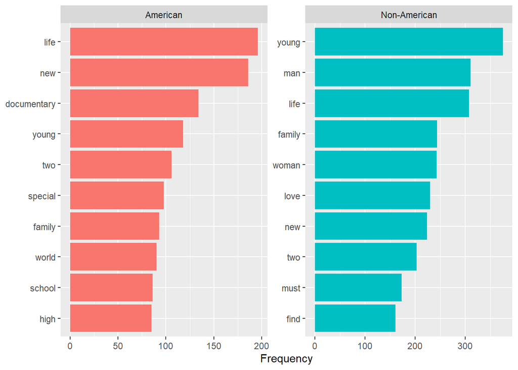

```r
# Word Frequency
movie_df %>%
  unnest_tokens(input = description, output = word) %>%
  anti_join(get_stopwords()) %>%
  count(american, word, sort = TRUE) %>%
  group_by(american) %>%
  slice_max(n, n = 10) %>%
  ungroup() %>%
  mutate(word = reorder_within(word, by = n, within = american)) %>%
  ggplot(aes(n, word, fill = american)) +
  geom_col(show.legend = FALSE) +
  facet_wrap(~american, scales = "free") +
  labs(x = "Frequency",
       y = NULL)+
  scale_y_reordered()
```

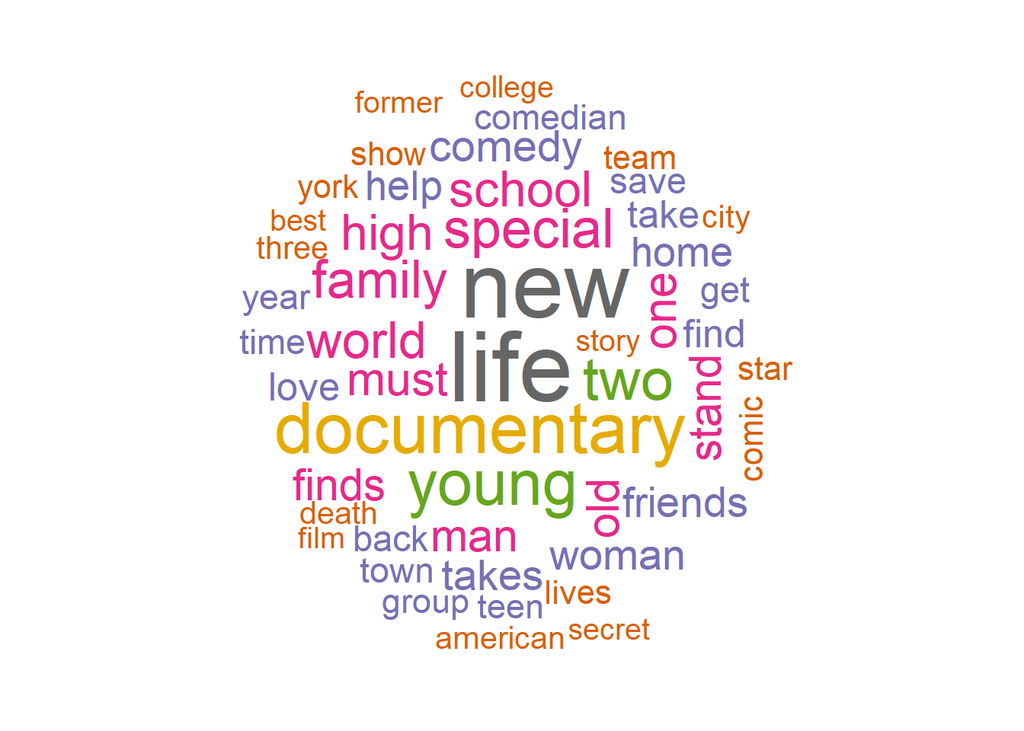

```r
# Wordclouds
movie_df %>%
  filter(american == 'American') %>%
  unnest_tokens(input = description, output = word) %>%
  anti_join(get_stopwords()) %>%
  count(type, word, sort = TRUE) %>%
  with(wordcloud(word, n, random.order = FALSE, max.words = 50, colors = colors))
```

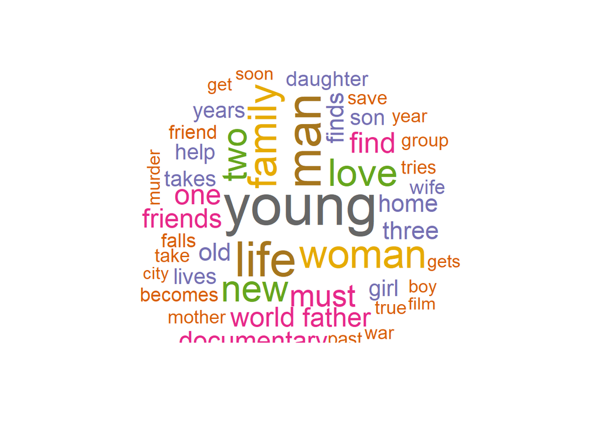

```r
movie_df %>%
  filter(american == 'Non-American') %>%
  unnest_tokens(input = description, output = word) %>%
  anti_join(get_stopwords()) %>%
  count(type, word, sort = TRUE) %>%
  with(wordcloud(word, n, random.order = FALSE, max.words = 50, colors = colors))
```

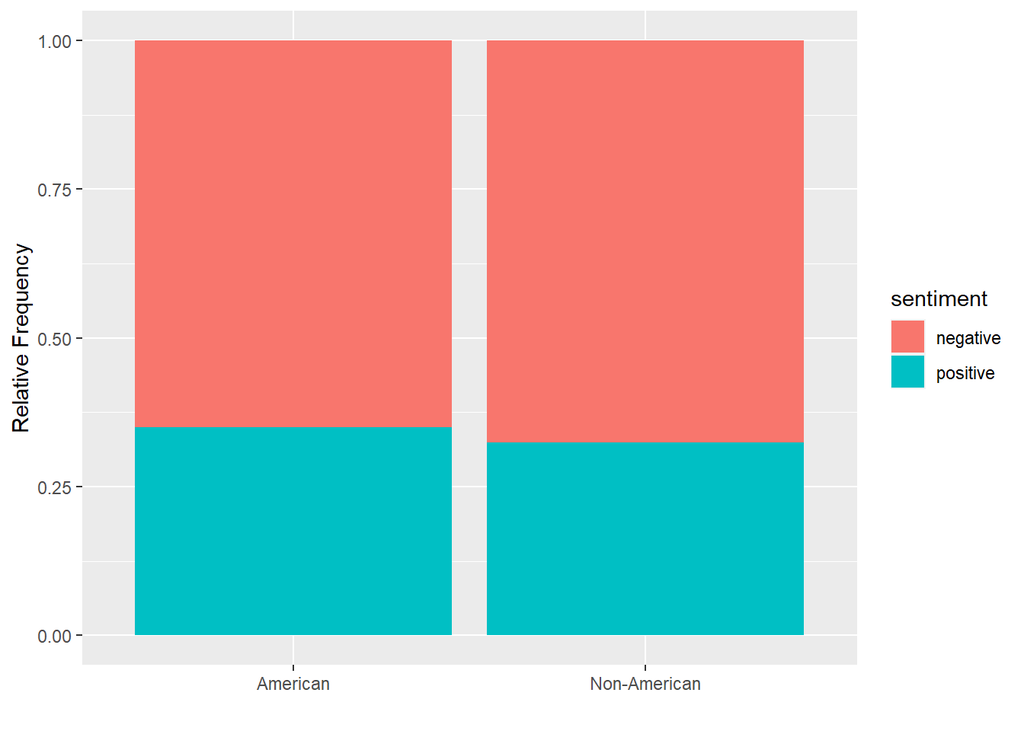

```r
############################# Sentiment analyses ###################################
# Bing
movie_df %>%
    unnest_tokens(input = description, output = word) %>%
    anti_join(get_stopwords()) %>%
    count(american, word, sort = TRUE) %>%
    group_by(american) %>%
    inner_join(get_sentiments("bing")) %>%
    filter(!is.na(sentiment)) %>%
    count(sentiment, sort = TRUE) %>%
    group_by(american) %>%
    mutate(n = n/sum(n)) %>%
    ggplot(aes(american, n, fill=sentiment))+geom_col(position = 'fill')+
    labs(y='Relative Frequency', x ='')
```

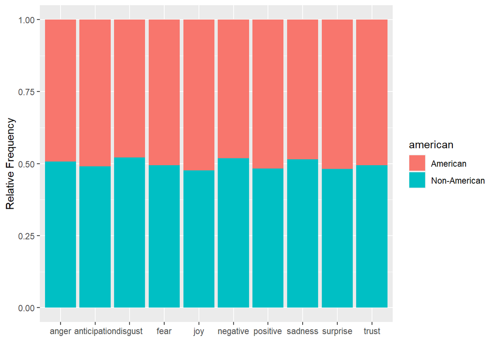

```r
# NRC
movie_df %>%
    unnest_tokens(input = description, output = word) %>%
    anti_join(get_stopwords()) %>%
    count(american, word, sort = TRUE) %>%
    group_by(american) %>%
    inner_join(get_sentiments("nrc")) %>%
    filter(!is.na(sentiment)) %>%
    count(sentiment, sort = TRUE) %>%
    group_by(american) %>%
    mutate(n = n/sum(n)) %>%
    ggplot(aes(sentiment, n, fill=american))+geom_col(position = 'fill')+
    labs(y='Relative Frequency', x ='')
```

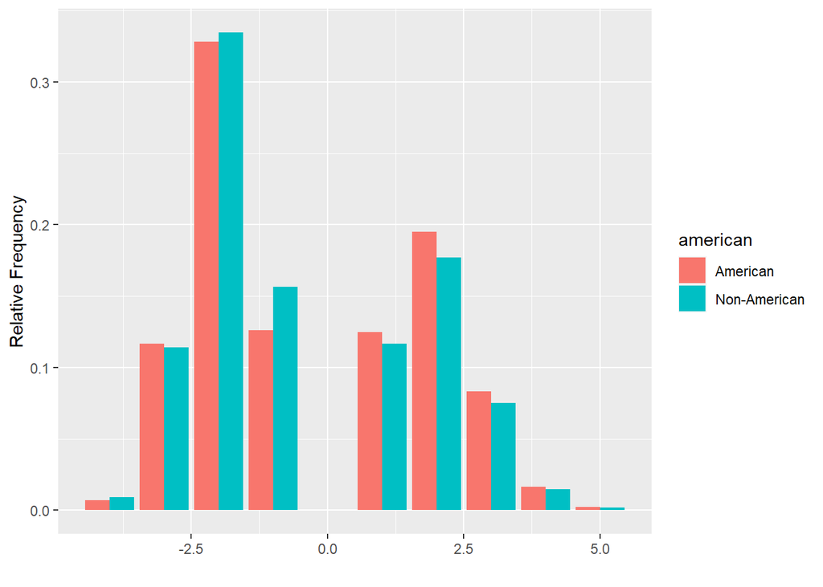

```r
# Afinn
movie_df %>%
    unnest_tokens(input = description, output = word) %>%
    anti_join(get_stopwords()) %>%
    count(american, word, sort = TRUE) %>%
    group_by(american) %>%
    inner_join(get_sentiments("afinn")) %>%
    mutate(sentiment = value) %>%
    filter(!is.na(sentiment)) %>%
    count(sentiment, sort = TRUE) %>%
    group_by(american) %>%
    mutate(n = n/sum(n)) %>%
    ggplot(aes(sentiment, n, fill= american))+geom_col(position = 'dodge')+
    labs(y='Relative Frequency', x ='')
```

```r
# Also can not run this cell due to textrecipes library (removed from CRAN repository as of 11/13/23). Also had to comment out so I could knit and submit this assignment.

####################################### Modeling #########################################

####################################### Giving Accuracy ##################################
# library(caret)
# library(themis)
# library(textrecipes)
#
# # Select data and set target
# model_df3 <- movie_df %>%
#   mutate(target = american) %>%
#   select(target, description)
#
# # Convert text data to numeric variables
# c <- recipe(target~description,
#        data = movie_df) %>%
#   step_tokenize(description) %>%
#   step_tokenfilter(description, max_tokens = 50) %>%
#   step_tfidf(description) %>%
#   step_normalize(all_numeric_predictors()) %>%
#   step_smote(target) %>%
#   prep()
# model_df3 <- juice(c)
#
# # Using Caret for modeling
# set.seed(2021)
# splitIndex <- createDataPartition(model_df3$target, p = .7,
#                                   list = FALSE)
# df_train3 <- model_df3[ splitIndex,]
# df_test3 <- model_df3[-splitIndex,]
#
# forest_ranger3 <- train(target~., data=df_train3,
#                         method = "ranger")
#
# pred3 <- predict(forest_ranger3, df_test3)
#
# cm3 <- confusionMatrix(data = pred3, reference = df_test3$target)
# cm3$overall[1]
#
# ############################### Plotting Confusion Matrix ################################
# d3 = data.frame(pred = pred3, obs = df_test3$target)
# library(yardstick)
# d3 %>% conf_mat(pred3, obs) %>% autoplot
```

### Animal Reviews Data (Optional)

We will study the Animal Crossing Data at [Kaggle](https://www.kaggle.com/jessemostipak/animal-crossing). The data file is `user_review`

**7.** Download the animal reviews data at this link. Read the data using `read_tsv()` function.

```r
animal_df <- read_tsv('user_reviews.tsv')
```

**8.** Create a `rating` variable taking value `good` if the grade is greater than 7 and `bad` otherwise.

```r
animal_df$rating <- case_when(animal_df$grade > 7 ~ 'good',
                              TRUE ~ 'bad')
```

**9.** Do the follows. Notice that the text information is in the `text` variable.

```
- Plot side-by-side word frequency by different categories of the `rating` variable

- Plot word clouds on different categories of the `rating` variable

- Do sentiment analysis to compare different categories of the `rating` variable

- Predict the rating using the reviews (`text` variable). Give the accuracy and plot the confusion matrix table.
```

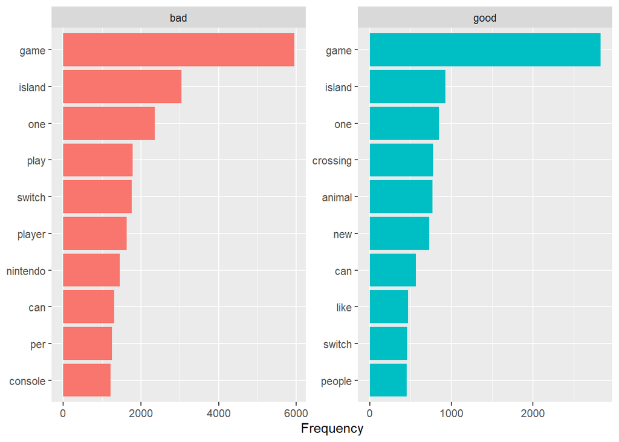

```r
# Word frequency
animal_df %>%
  unnest_tokens(input = text, output = word) %>%
  anti_join(get_stopwords()) %>%
  count(rating, word, sort = TRUE) %>%
  group_by(rating) %>%
  slice_max(n, n = 10) %>%
  ungroup() %>%
  mutate(word = reorder_within(word, by = n, within = rating)) %>%
  ggplot(aes(n, word, fill = rating)) +
  geom_col(show.legend = FALSE) +
  facet_wrap(~rating, scales = "free") +
  labs(x = "Frequency",
       y = NULL)+
  scale_y_reordered()
```

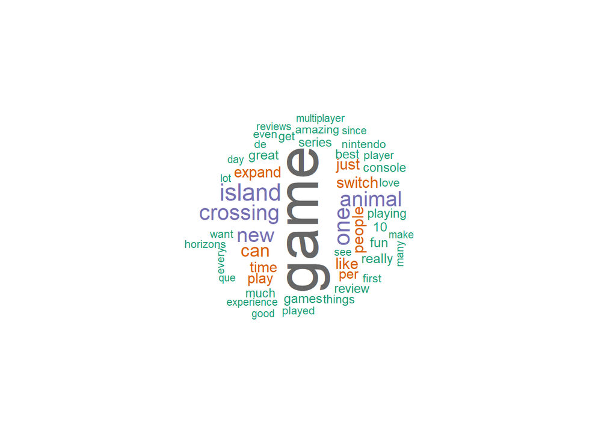

```r
# Word clouds
animal_df %>%
  filter(rating == 'good') %>%
  unnest_tokens(input = text, output = word) %>%
  anti_join(get_stopwords()) %>%
  count(rating, word, sort = TRUE) %>%
  with(wordcloud(word, n, random.order = FALSE, max.words = 50, colors=colors))
```

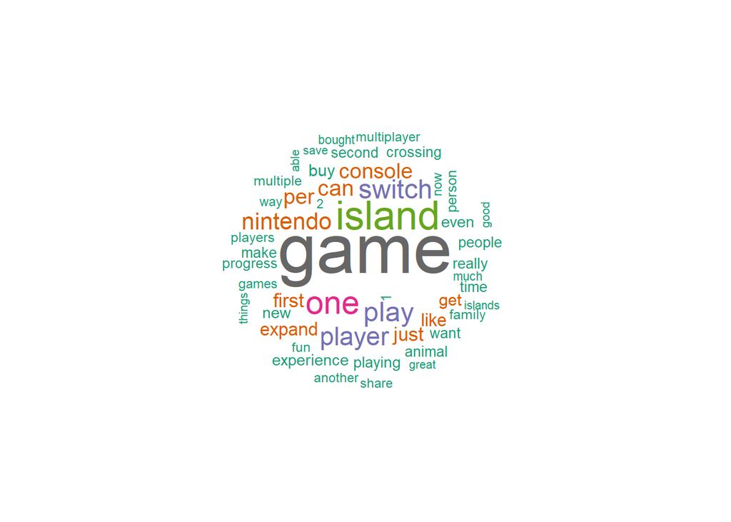

```r
animal_df %>%
  filter(rating == 'bad') %>%
  unnest_tokens(input = text, output = word) %>%
  anti_join(get_stopwords()) %>%
  count(rating, word, sort = TRUE) %>%
  with(wordcloud(word, n, random.order = FALSE, max.words = 50, colors=colors))
```

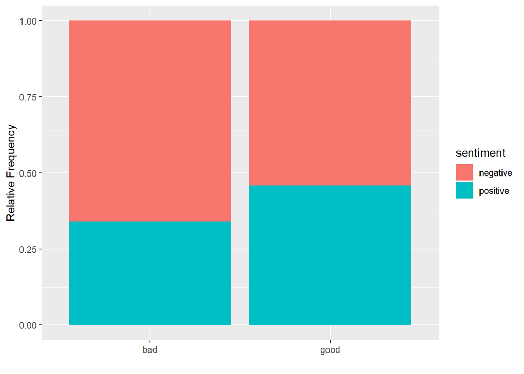

```r
############################## Sentiment Analysis ########################################

# Bing
animal_df %>%
    unnest_tokens(input = text, output = word) %>%
    anti_join(get_stopwords()) %>%
    count(rating, word, sort = TRUE) %>%
    group_by(rating) %>%
    inner_join(get_sentiments("bing")) %>%
    filter(!is.na(sentiment)) %>%
    count(sentiment, sort = TRUE) %>%
    group_by(rating) %>%
    mutate(n = n/sum(n)) %>%
    ggplot(aes(rating, n, fill=sentiment))+geom_col(position = 'fill')+
    labs(y='Relative Frequency', x ='')
```

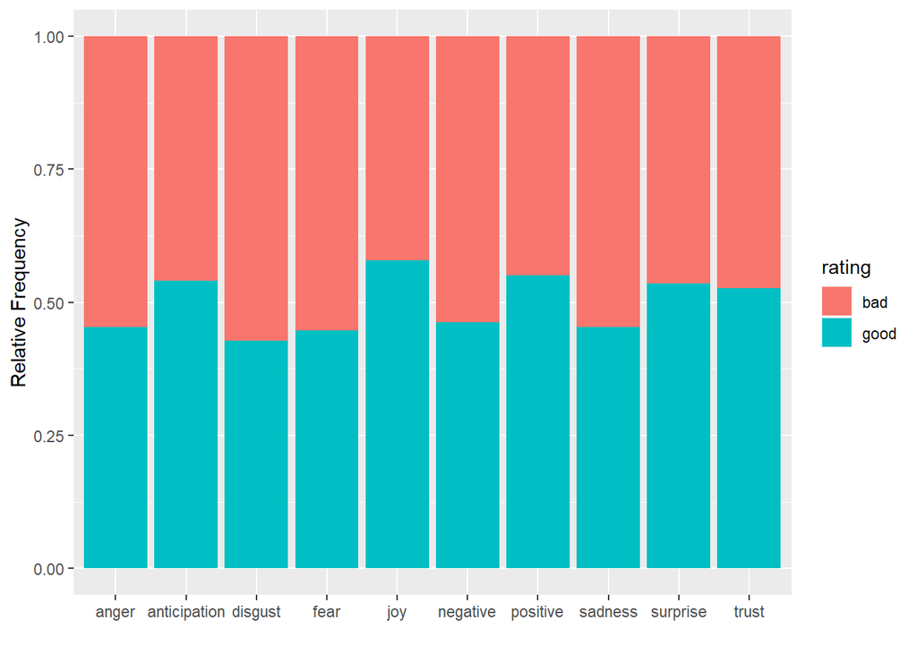

```r
# NRC
animal_df %>%
    unnest_tokens(input = text, output = word) %>%
    anti_join(get_stopwords()) %>%
    count(rating, word, sort = TRUE) %>%
    group_by(rating) %>%
    inner_join(get_sentiments("nrc")) %>%
    filter(!is.na(sentiment)) %>%
    count(sentiment, sort = TRUE) %>%
    group_by(rating) %>%
    mutate(n = n/sum(n)) %>%
    ggplot(aes(sentiment, n, fill=rating))+geom_col(position = 'fill')+
    labs(y='Relative Frequency', x ='')
```

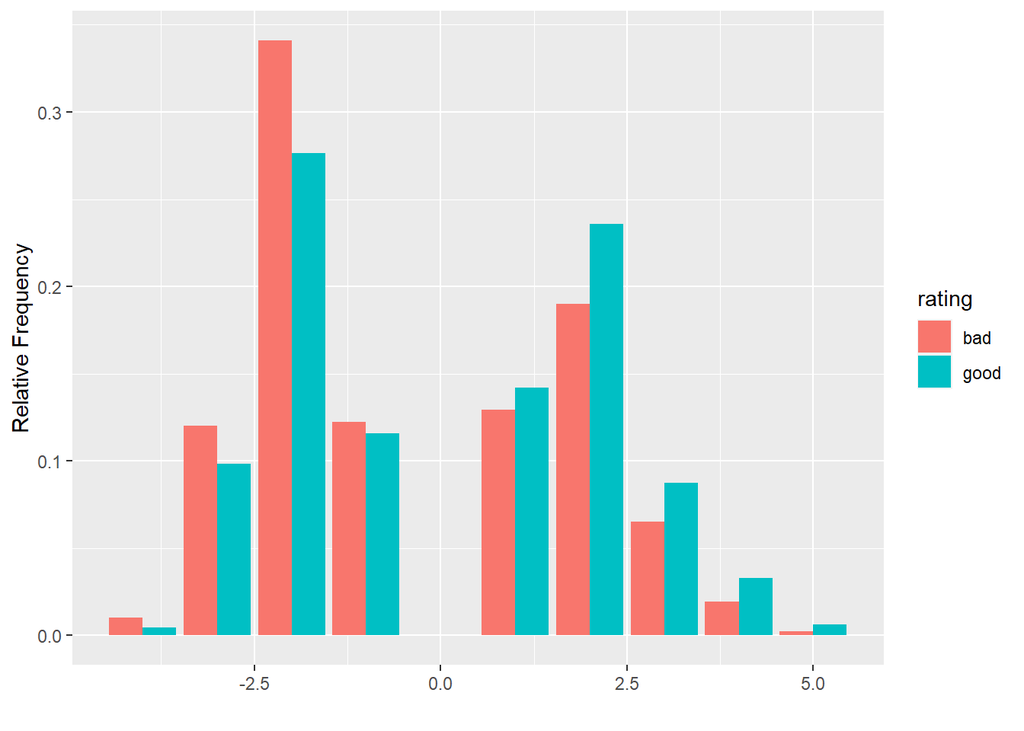

```r
# Afinn
animal_df %>%
    unnest_tokens(input = text, output = word) %>%
    anti_join(get_stopwords()) %>%
    count(rating, word, sort = TRUE) %>%
    group_by(rating) %>%
    inner_join(get_sentiments("afinn")) %>%
    mutate(sentiment = value) %>%
    filter(!is.na(sentiment)) %>%
    count(sentiment, sort = TRUE) %>%
    group_by(rating) %>%
    mutate(n = n/sum(n)) %>%
    ggplot(aes(sentiment, n, fill= rating))+geom_col(position = 'dodge')+
    labs(y='Relative Frequency', x ='')
```

```r
# Also can not run this cell due to textrecipes library (removed from CRAN repository as of 11/13/23). Also had to comment out so I could knit and submit this assignment.

####################################### Modeling #########################################

####################################### Giving Accuracy ##################################
# library(caret)
# library(themis)
# library(textrecipes)
#
# # Select data and set target
# model_df4 <- animal_df %>%
#   mutate(target = rating) %>%
#   select(target, text)
#
# # Convert text data to numeric variables
# d <- recipe(target~text,
#        data = animal_df) %>%
#   step_tokenize(text) %>%
#   step_tokenfilter(text, max_tokens = 50) %>%
#   step_tfidf(text) %>%
#   step_normalize(all_numeric_predictors()) %>%
#   step_smote(target) %>%
#   prep()
# model_df4 <- juice(d)
#
# # Using Caret for modeling
# set.seed(2021)
# splitIndex <- createDataPartition(model_df4$target, p = .7,
#                                   list = FALSE)
# df_train4 <- model_df4[ splitIndex,]
# df_test4 <- model_df4[-splitIndex,]
#
# forest_ranger4 <- train(target~., data=df_train4,
#                         method = "ranger")
#
# pred4 <- predict(forest_ranger4, df_test4)
#
# cm4 <- confusionMatrix(data = pred4, reference = df_test4$target)
# cm4$overall[1]
#
# ############################### Plotting Confusion Matrix ################################
# d4 = data.frame(pred = pred4, obs = df_test4$target)
# library(yardstick)
# d4 %>% conf_mat(pred4, obs) %>% autoplot
```